# Qüestionari 3

# Pregunta 2

Sigui X la següent mostra:

```
0.6, 2.2, 0.5, 0.5, 0.9, 0.3, 0.2, 0.3, 1.2, 0.3
```

Utilitzant un gràfic Q-Q, volem veure si la mostra s’ajusta a una distribució uniforme amb paràmetres $a=0$ i $b=2.5$. Quin dels següents gràfics obtindrem?

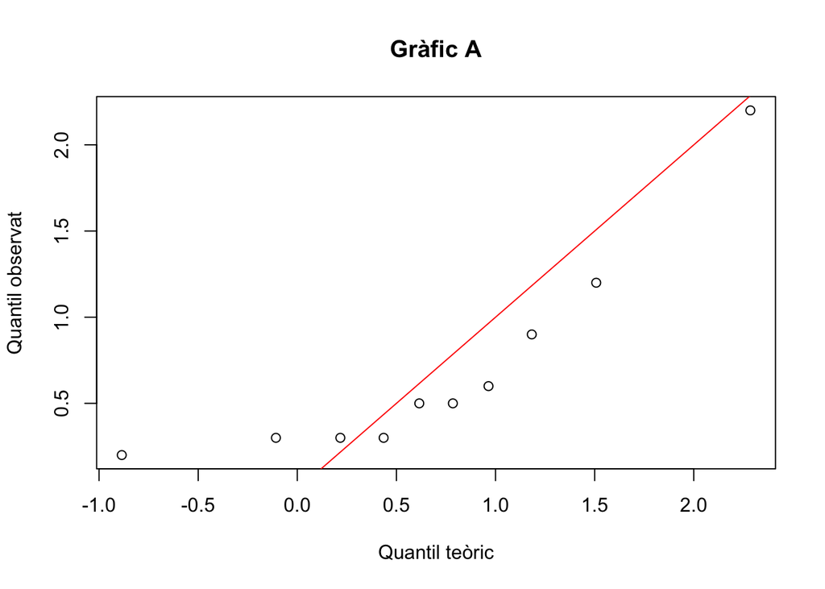

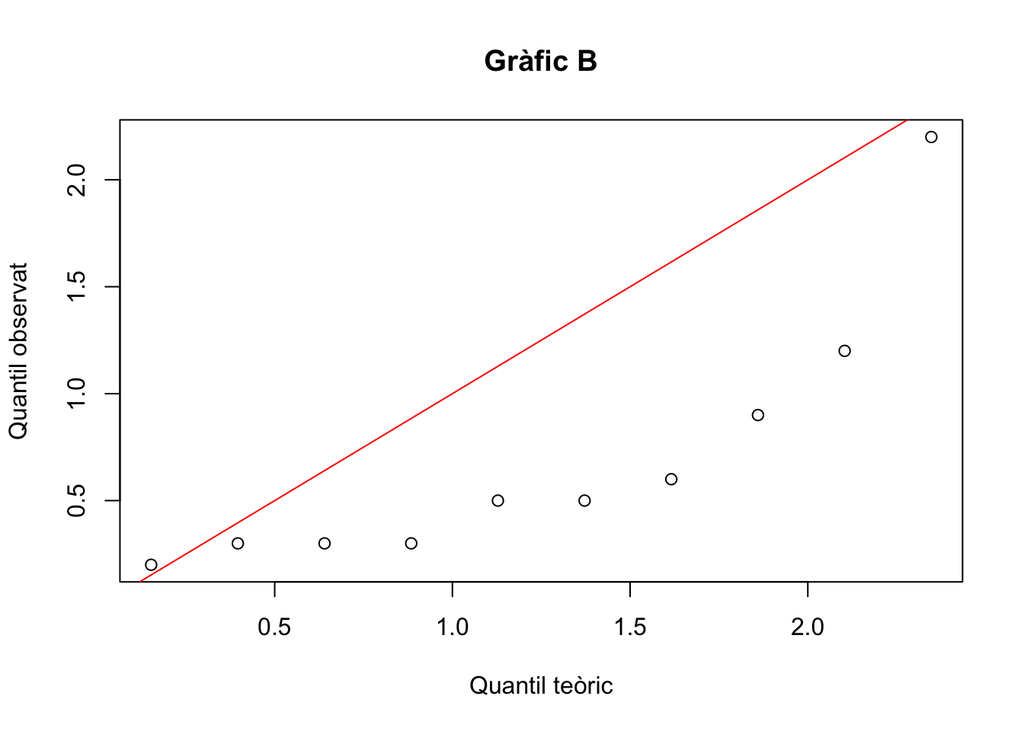

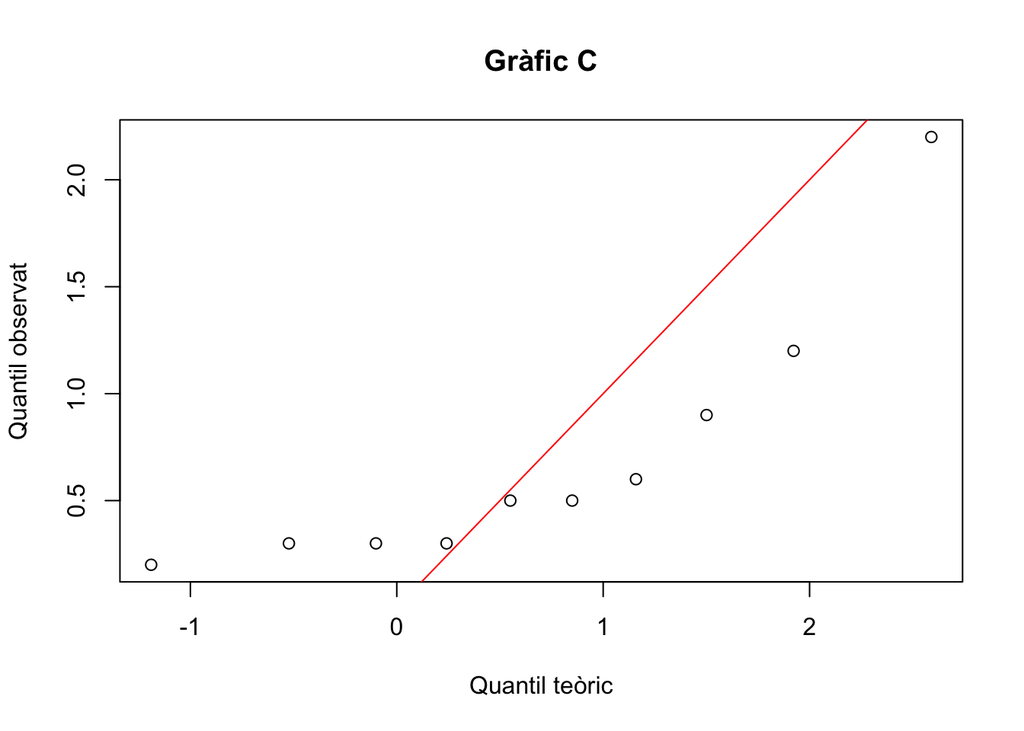

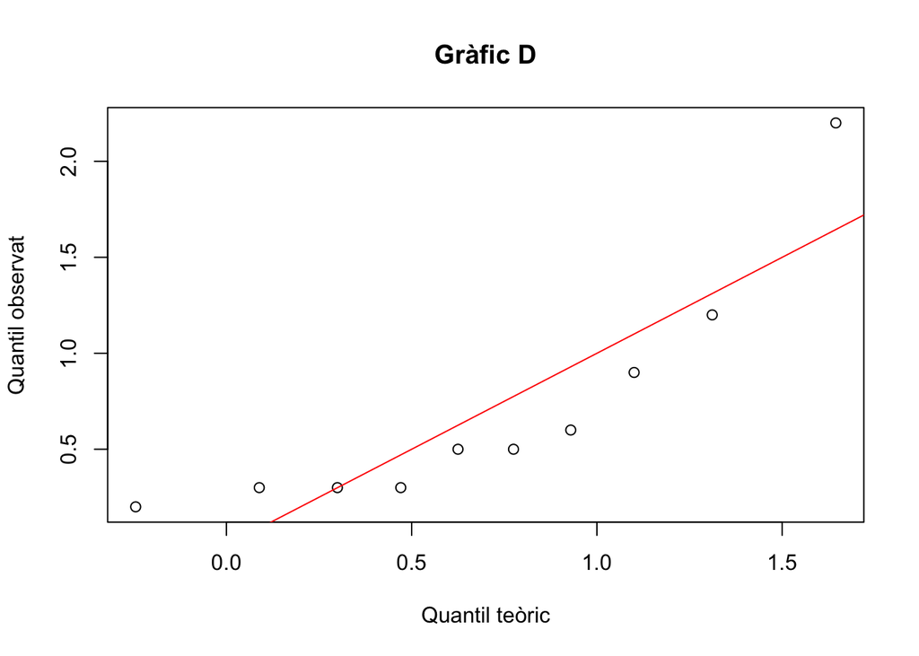

## Resposta

Amb el vector donat:

```r
X = c(0.6, 2.2, 0.5, 0.5, 0.9, 0.3, 0.2, 0.3, 1.2, 0.3)
```

Per veure si les dades s’ajusten a una distribució uniforme, necessitem comparar els quantils observats amb els quantils teòrics:

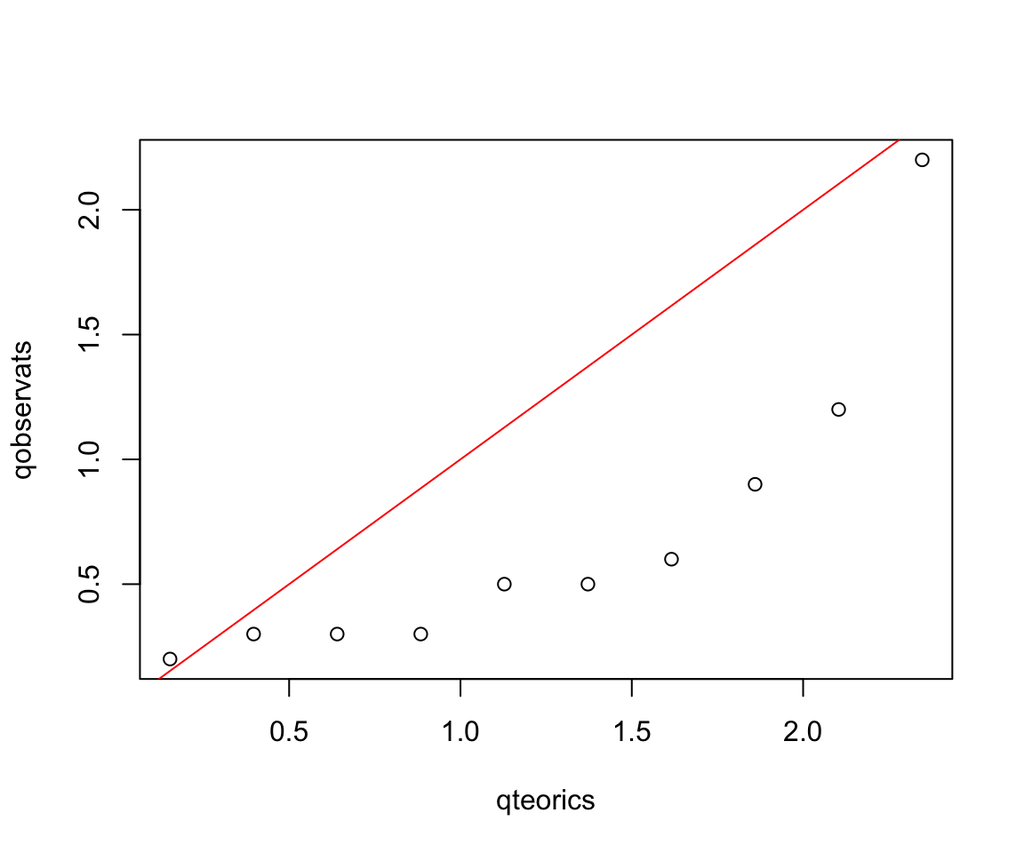

```r
qobservats = sort(X)
qteorics = qunif(ppoints(10), 0, 2.5)
qqplot(qteorics, qobservats)
abline(0,1,col='red')
```

Com veiem, el gràfic B és el que mostra l’ajust de les dades a la distribució demanada.

# Pregunta 3

Un jugador juga a un joc en què ha de llençar 5 daus seguits. Els seus beneficis estan relacionats amb el nombre de sisos que treu. Després de jugar 100 vegades, ha registrat els següents resultats:

| # de sisos | n |
| --- | --- |
| 0 | 37 |
| 1 | 47 |
| 2 | 12 |
| 3 | 4 |
| 4 | 0 |
| 5 | 0 |

1. Primerament vol mirar si el dau està trucat, per això realitzarà un contrast de bondat d’ajust per veure si la distribució del nombre de sisos observats en les 100 repeticions és com s’esperaria. Quin és el valor p que obtindrà? (no utilitzis la correcció de continuïtat)
2. Després de pensar-hi, veu que realment ha llençat el dau 500 vegades. Fes un contrast per veure si el nombre de sisos que ha obtingut en aquests 500 llançaments segueix la distribució que hauria de seguir. Quin és el valor p que obtindrà? (no utilitzis la correcció de continuïtat)
3. Si les recompenses del joc són -1, 0, 1, 4, 16, 64 euros per obtenir 0, 1, 2, 3, 4, 5 sisos respectivament, quina és la recompensa esperada per cada euro jugat? (si en lloc de recompensa et surt pèrdua, indica-ho amb un valor negatiu)

## Resposta

```r
E = 100 * dbinom(0:5, 5, 1/6)
O = c(37, 47, 12, 4, 0, 0)
1 - pchisq( sum( (O-E)^2 / E ), df = 6-1)
# > [1] 0.7051227
```

```r
UNS = sum( 0:5 * c(37, 47, 12, 4, 0, 0) )
E = 500 * dbinom(0:1, 1, 1/6)
O = c(500 - UNS, UNS)
1 - pchisq( sum( (O-E)^2 / E ), df = 2-1)
# > [1] 0.9680931
```

3. La recompensa vindrà donada per sumar pels resultats de multiplicar la probabilitat de cada esdeveniment per la recompensa de l’esdeveniment:

```r
recomp = c(-1,0,4^(0:3))
p_n_uns = dbinom(0:5, 5, 1/6)
sum(p_n_uns * recomp)
# > [1] -0.05285494
```

# Pregunta 4

El teorema del límit central diu que si calculem la mitjana de mostres provinents d’una mateixa variable aleatòria, aquesta mitjana es comportarà com si provingués d’una distribució normal. A continuació, tens 10 mostres de llargada 20 obtingudes d’una mateixa variable aleatòria. Realitza el contrast de Shapiro-Wilk per veure si es compleix el teorema del límit central. Quin és el p-valor obtingut?

| A | B | C | D | E | F | G | H | I | J |
| --- | --- | --- | --- | --- | --- | --- | --- | --- | --- |
| 3 | 9 | 1 | 8 | 4 | 5 | 4 | 10 | 8 | 4 |
| 5 | 4 | 9 | 9 | 6 | 6 | 2 | 3 | 7 | 8 |
| 5 | 4 | 3 | 8 | 4 | 5 | 3 | 5 | 3 | 1 |
| 2 | 9 | 6 | 3 | 7 | 1 | 2 | 7 | 5 | 4 |
| 5 | 6 | 1 | 6 | 7 | 2 | 3 | 1 | 1 | 4 |
| 1 | 7 | 8 | 10 | 6 | 5 | 2 | 1 | 4 | 2 |
| 3 | 6 | 3 | 10 | 4 | 4 | 5 | 1 | 10 | 6 |
| 2 | 9 | 8 | 3 | 5 | 9 | 8 | 9 | 6 | 10 |
| 3 | 3 | 3 | 3 | 3 | 5 | 0 | 7 | 7 | 10 |
| 9 | 2 | 2 | 2 | 6 | 3 | 5 | 1 | 3 | 2 |
| 4 | 9 | 5 | 3 | 9 | 3 | 9 | 5 | 4 | 5 |
| 8 | 5 | 3 | 5 | 1 | 8 | 4 | 5 | 10 | 4 |
| 9 | 9 | 2 | 9 | 4 | 7 | 0 | 4 | 9 | 7 |
| 4 | 2 | 5 | 5 | 2 | 2 | 1 | 10 | 10 | 3 |
| 1 | 8 | 6 | 3 | 4 | 1 | 3 | 2 | 8 | 5 |
| 3 | 7 | 1 | 0 | 1 | 8 | 2 | 8 | 8 | 2 |
| 7 | 9 | 3 | 4 | 5 | 6 | 1 | 1 | 3 | 4 |
| 3 | 5 | 7 | 9 | 9 | 2 | 2 | 4 | 8 | 7 |
| 6 | 7 | 10 | 3 | 8 | 1 | 2 | 1 | 10 | 5 |
| 8 | 4 | 1 | 1 | 9 | 1 | 1 | 2 | 3 | 1 |

Pots utilitzar el següent codi per importar els valors en una taula:

```
dades = structure(list(mostra = c("A", "A", "A", "A", "A", "A", "A",
"A", "A", "A", "A", "A", "A", "A", "A", "A", "A", "A", "A", "A",
"B", "B", "B", "B", "B", "B", "B", "B", "B", "B", "B", "B", "B",
"B", "B", "B", "B", "B", "B", "B", "C", "C", "C", "C", "C", "C",
"C", "C", "C", "C", "C", "C", "C", "C", "C", "C", "C", "C", "C",
"C", "D", "D", "D", "D", "D", "D", "D", "D", "D", "D", "D", "D",
"D", "D", "D", "D", "D", "D", "D", "D", "E", "E", "E", "E", "E",
"E", "E", "E", "E", "E", "E", "E", "E", "E", "E", "E", "E", "E",
"E", "E", "F", "F", "F", "F", "F", "F", "F", "F", "F", "F", "F",
"F", "F", "F", "F", "F", "F", "F", "F", "F", "G", "G", "G", "G",
"G", "G", "G", "G", "G", "G", "G", "G", "G", "G", "G", "G", "G",
"G", "G", "G", "H", "H", "H", "H", "H", "H", "H", "H", "H", "H",
"H", "H", "H", "H", "H", "H", "H", "H", "H", "H", "I", "I", "I",
"I", "I", "I", "I", "I", "I", "I", "I", "I", "I", "I", "I", "I",
"I", "I", "I", "I", "J", "J", "J", "J", "J", "J", "J", "J", "J",
"J", "J", "J", "J", "J", "J", "J", "J", "J", "J", "J"), valor = c(3,
5, 5, 2, 5, 1, 3, 2, 3, 9, 4, 8, 9, 4, 1, 3, 7, 3, 6, 8, 9, 4,
4, 9, 6, 7, 6, 9, 3, 2, 9, 5, 9, 2, 8, 7, 9, 5, 7, 4, 1, 9, 3,
6, 1, 8, 3, 8, 3, 2, 5, 3, 2, 5, 6, 1, 3, 7, 10, 1, 8, 9, 8,
3, 6, 10, 10, 3, 3, 2, 3, 5, 9, 5, 3, 0, 4, 9, 3, 1, 4, 6, 4,
7, 7, 6, 4, 5, 3, 6, 9, 1, 4, 2, 4, 1, 5, 9, 8, 9, 5, 6, 5, 1,
2, 5, 4, 9, 5, 3, 3, 8, 7, 2, 1, 8, 6, 2, 1, 1, 4, 2, 3, 2, 3,
2, 5, 8, 0, 5, 9, 4, 0, 1, 3, 2, 1, 2, 2, 1, 10, 3, 5, 7, 1,
1, 1, 9, 7, 1, 5, 5, 4, 10, 2, 8, 1, 4, 1, 2, 8, 7, 3, 5, 1,
4, 10, 6, 7, 3, 4, 10, 9, 10, 8, 8, 3, 8, 10, 3, 4, 8, 1, 4,
4, 2, 6, 10, 10, 2, 5, 4, 7, 3, 5, 2, 4, 7, 5, 1)), row.names = c(NA,
-200L), class = c("tbl_df", "tbl", "data.frame"))
```

## Resposta

Comencem carregant les dades:

```r
dades = structure(list(mostra = c("A", "A", "A", "A", "A", "A", "A",
"A", "A", "A", "A", "A", "A", "A", "A", "A", "A", "A", "A", "A",
"B", "B", "B", "B", "B", "B", "B", "B", "B", "B", "B", "B", "B",
"B", "B", "B", "B", "B", "B", "B", "C", "C", "C", "C", "C", "C",
"C", "C", "C", "C", "C", "C", "C", "C", "C", "C", "C", "C", "C",
"C", "D", "D", "D", "D", "D", "D", "D", "D", "D", "D", "D", "D",
"D", "D", "D", "D", "D", "D", "D", "D", "E", "E", "E", "E", "E",
"E", "E", "E", "E", "E", "E", "E", "E", "E", "E", "E", "E", "E",
"E", "E", "F", "F", "F", "F", "F", "F", "F", "F", "F", "F", "F",
"F", "F", "F", "F", "F", "F", "F", "F", "F", "G", "G", "G", "G",
"G", "G", "G", "G", "G", "G", "G", "G", "G", "G", "G", "G", "G",
"G", "G", "G", "H", "H", "H", "H", "H", "H", "H", "H", "H", "H",
"H", "H", "H", "H", "H", "H", "H", "H", "H", "H", "I", "I", "I",
"I", "I", "I", "I", "I", "I", "I", "I", "I", "I", "I", "I", "I",
"I", "I", "I", "I", "J", "J", "J", "J", "J", "J", "J", "J", "J",
"J", "J", "J", "J", "J", "J", "J", "J", "J", "J", "J"), valor = c(3,
5, 5, 2, 5, 1, 3, 2, 3, 9, 4, 8, 9, 4, 1, 3, 7, 3, 6, 8, 9, 4,
4, 9, 6, 7, 6, 9, 3, 2, 9, 5, 9, 2, 8, 7, 9, 5, 7, 4, 1, 9, 3,
6, 1, 8, 3, 8, 3, 2, 5, 3, 2, 5, 6, 1, 3, 7, 10, 1, 8, 9, 8,
3, 6, 10, 10, 3, 3, 2, 3, 5, 9, 5, 3, 0, 4, 9, 3, 1, 4, 6, 4,
7, 7, 6, 4, 5, 3, 6, 9, 1, 4, 2, 4, 1, 5, 9, 8, 9, 5, 6, 5, 1,
2, 5, 4, 9, 5, 3, 3, 8, 7, 2, 1, 8, 6, 2, 1, 1, 4, 2, 3, 2, 3,
2, 5, 8, 0, 5, 9, 4, 0, 1, 3, 2, 1, 2, 2, 1, 10, 3, 5, 7, 1,
1, 1, 9, 7, 1, 5, 5, 4, 10, 2, 8, 1, 4, 1, 2, 8, 7, 3, 5, 1,
4, 10, 6, 7, 3, 4, 10, 9, 10, 8, 8, 3, 8, 10, 3, 4, 8, 1, 4,
4, 2, 6, 10, 10, 2, 5, 4, 7, 3, 5, 2, 4, 7, 5, 1)), row.names = c(NA,
-200L), class = c("tbl_df", "tbl", "data.frame"))
```

Per veure si es compleix el teorema central del límit, necessitem veure si la mitjana d’aquestes 10 mostres segueix o no una distribució normal. Començarem calculant la mitjana de les 10 mostres.

```r
mitj_mostres = dades %>%
  group_by(mostra) %>%
  summarise(.groups = 'drop', x_mean = mean(valor))
```

Amb les mitjanes, mirem si segueix una distribució normal.

```r
shapiro.test(mitj_mostres$x_mean)
# >
# >     Shapiro-Wilk normality test
# >
# > data:  mitj_mostres$x_mean
# > W = 0.94123, p-value = 0.5667
```